# Exploring data from the GESIS German General Social Survey - ALLBUS 2021

R User

2022-08-19

#Data Wrangling

```r
library(tidyverse)
library(naniar)
library(sjlabelled)
library(haven)

inverter <- function (var) {
  max(var, na.rm = TRUE) - var + 1
}

allbus_2021 <- read_sav("../data/allbus_2021/ZA5280_v1-0-0.sav") %>%
  remove_all_labels()

allbus_2021_subset  <- allbus_2021  %>%
  select(respid,
         sex,
         agec,
         educ,
         left_right = pa01,
         party_vote = pv01,
         sat_dem = ps03,
         xeno1 = ma01b,
         xeno2 = ma02,
         xeno3 = ma03,
         xeno4 = ma04,
         contact1 = mc01,
         contact2 = mc02,
         contact3 = mc03,
         contact4 = mc04,
         trust_gov = pt12,
         life_satf = ls01
  ) %>%
  replace_with_na_all(condition = ~.x < 0)  %>%
  mutate(sex = recode_factor(sex,
                             `1`= "Male",
                             `2` = "Female",
                             `3` = "Non-binary"),
         sat_dem = recode(sat_dem,
                          `1` = 6,
                          `2` = 5,
                          `3` = 4,
                          `4` = 3,
                          `5` = 3,
                          `6`= 1),
         agec = recode_factor(agec,
                              `1`= "<= 25 years",
                              `2`= "26 to 30 years",
                              `3` = "31 to 35 years",
                              `4` = "36 to 40 years",
                              `5` = "41 to 45 years",
                              `6` = "46 to 50 years",
                              .ordered = TRUE),
         party_vote = recode_factor(party_vote,
                                    `1`= "CDU-CSU",
                                    `2`= "SPD",
                                    `3` = "FDP",
                                    `4` = "Gruene",
                                    `6` = "Linke",
                                    `42` = "AfD",
                                    `90` = "Other party",
                                    `91` = "Would not vote"),
         distrust_gov = inverter(trust_gov)) %>%
  mutate(
    xenophobia = rowMeans(across(
      xeno1:xeno4))) %>%
  mutate(across(contact1:contact4,
                ~recode(
                  .x,
                  `2` = 0))) %>%
  mutate(contact = rowSums(across(
    contact1:contact4)))
```

# 1 The data

The data we use comes from the [German General Social Survey - ALLBUS 2021](https://search.gesis.org/research_data/ZA5280).We have selected 20 variables of interest for our analysis. The dataset includes data for *N* = 5342 respondents.

## 1.1 Missing data

As not all of the respondents answered every question in the survey, we have missing data. Before we further explore the data, we want to know whether there are identifiable patterns of missingness in them.

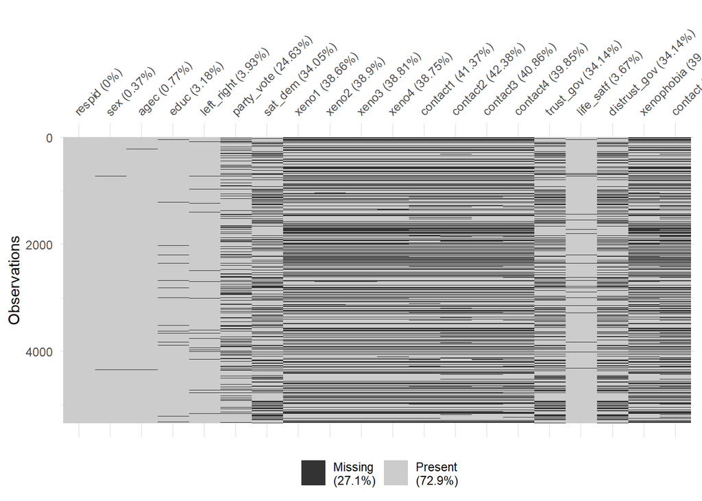

```r
library(visdat)

vis_miss(allbus_2021_subset)
```

# 2 Exploring the *GESIS German General Social Survey - ALLBUS 2021* dataset

## 2.1 Demographics

We first want to look at gender, age (categories), education, and party vote in our sample.

```r
library(janitor)

allbus_2021_subset %>%
  tabyl(sex) %>%
  adorn_totals("row") %>%
  adorn_pct_formatting() %>%
  knitr::kable()
```

| sex | n | percent | valid_percent |
| --- | --- | --- | --- |
| Male | 2614 | 48.9% | 49.1% |
| Female | 2705 | 50.6% | 50.8% |
| Non-binary | 3 | 0.1% | 0.1% |
| NA | 20 | 0.4% | - |
| Total | 5342 | 100.0% | 100.0% |

```r
allbus_2021_subset %>%
  tabyl(agec) %>%
  adorn_totals("row") %>%
  adorn_pct_formatting() %>%
  knitr::kable()
```

| agec | n | percent | valid_percent |
| --- | --- | --- | --- |
| <= 25 years | 618 | 11.6% | 11.7% |
| 26 to 30 years | 1136 | 21.3% | 21.4% |
| 31 to 35 years | 1448 | 27.1% | 27.3% |
| 36 to 40 years | 1450 | 27.1% | 27.4% |
| 41 to 45 years | 617 | 11.5% | 11.6% |
| 46 to 50 years | 32 | 0.6% | 0.6% |
| NA | 41 | 0.8% | - |
| Total | 5342 | 100.0% | 100.0% |

```r
allbus_2021_subset %>%
  tabyl(educ) %>%
  adorn_totals("row") %>%
  adorn_pct_formatting() %>%
  knitr::kable()
```

| educ | n | percent | valid_percent |
| --- | --- | --- | --- |
| 1 | 67 | 1.3% | 1.3% |
| 2 | 925 | 17.3% | 17.9% |
| 3 | 1648 | 30.8% | 31.9% |
| 4 | 704 | 13.2% | 13.6% |
| 5 | 1784 | 33.4% | 34.5% |
| 6 | 29 | 0.5% | 0.6% |
| 7 | 15 | 0.3% | 0.3% |
| NA | 170 | 3.2% | - |
| Total | 5342 | 100.0% | 100.0% |

```r
allbus_2021_subset %>%
  tabyl(party_vote) %>%
  adorn_totals("row") %>%
  adorn_pct_formatting() %>%
  knitr::kable()
```

| party_vote | n | percent | valid_percent |
| --- | --- | --- | --- |
| CDU-CSU | 1043 | 19.5% | 25.9% |
| SPD | 595 | 11.1% | 14.8% |
| FDP | 475 | 8.9% | 11.8% |
| Gruene | 944 | 17.7% | 23.4% |
| Linke | 305 | 5.7% | 7.6% |
| AfD | 275 | 5.1% | 6.8% |
| Other party | 163 | 3.1% | 4.0% |
| Would not vote | 226 | 4.2% | 5.6% |
| NA | 1316 | 24.6% | - |
| Total | 5342 | 100.0% | 100.0% |

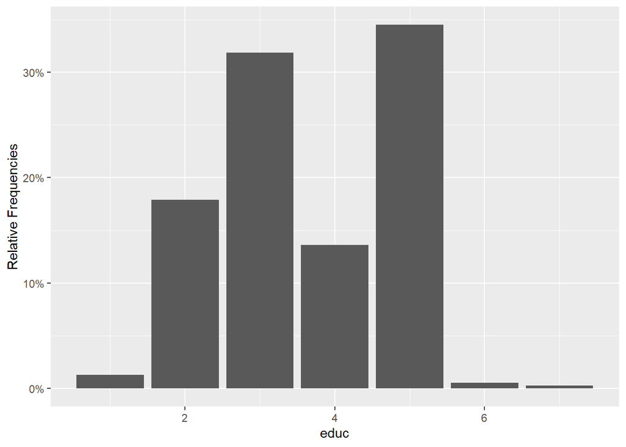

```r
allbus_2021_subset %>%
  ggplot(aes(x = educ,
             fill = educ)) +
  geom_bar(aes(y = (..count..)/sum(..count..))) +
  scale_y_continuous(labels=scales::percent) +
  ylab("Relative Frequencies")
```

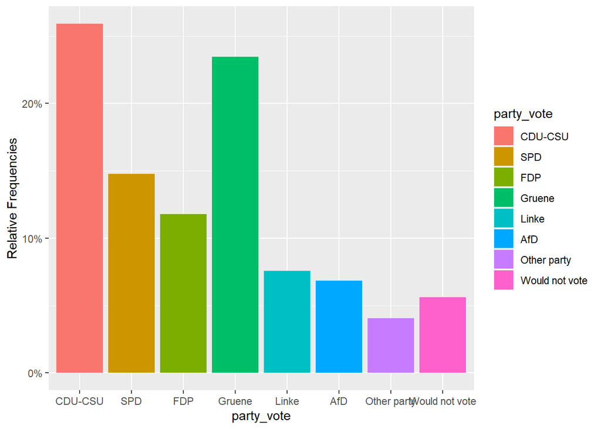

```r
allbus_2021_subset %>%
  filter(!is.na(party_vote)) %>%
  ggplot(aes(x = party_vote,
             fill = party_vote)) +
  geom_bar(aes(y = (..count..)/sum(..count..))) +
  scale_y_continuous(labels=scales::percent) +
  ylab("Relative Frequencies")
```

## 2.2 Summary statistics

Let’s look at the summary statistic for the items on xenophobia.

```r
library(pander)

allbus_2021_subset %>%
  select(starts_with("xeno")) %>%
  summary() %>%
  pander()
```

| xeno1 | xeno2 | xeno3 | xeno4 | xenophobia |
| --- | --- | --- | --- | --- |
| Min. :1.000 | Min. :1.000 | Min. :1.000 | Min. :1.00 | Min. :1.000 |
| 1st Qu.:4.000 | 1st Qu.:1.000 | 1st Qu.:1.000 | 1st Qu.:1.00 | 1st Qu.:2.000 |
| Median :5.000 | Median :2.000 | Median :2.000 | Median :1.00 | Median :2.750 |
| Mean :5.114 | Mean :2.579 | Mean :2.845 | Mean :1.86 | Mean :3.097 |
| 3rd Qu.:7.000 | 3rd Qu.:4.000 | 3rd Qu.:4.000 | 3rd Qu.:2.00 | 3rd Qu.:4.000 |
| Max. :7.000 | Max. :7.000 | Max. :7.000 | Max. :7.00 | Max. :7.000 |
| NA’s :2065 | NA’s :2078 | NA’s :2073 | NA’s :2070 | NA’s :2105 |

## 2.3 Distribution of variables

We want to explore how some of the data for the question on life satisfaction and political orientation (left-right) are distributed in our sample.

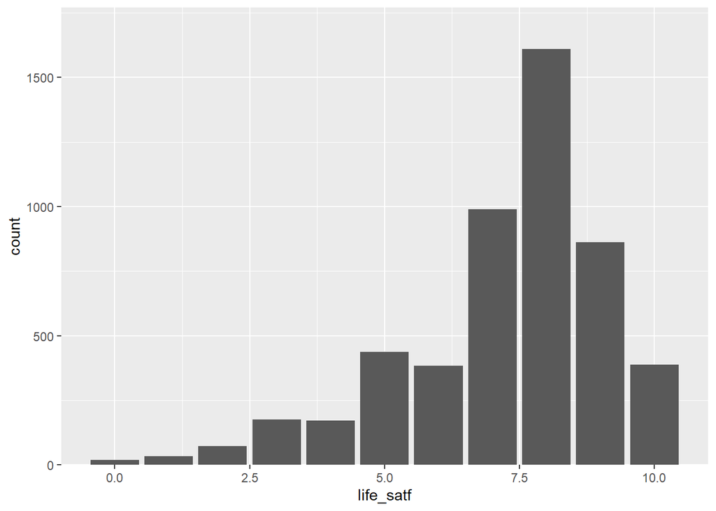

```r
allbus_2021_subset %>%
  ggplot(aes(x = life_satf)) +
  geom_bar() +
  scale_y_continuous(expand=expansion(mult=c(0,0.1)))
```

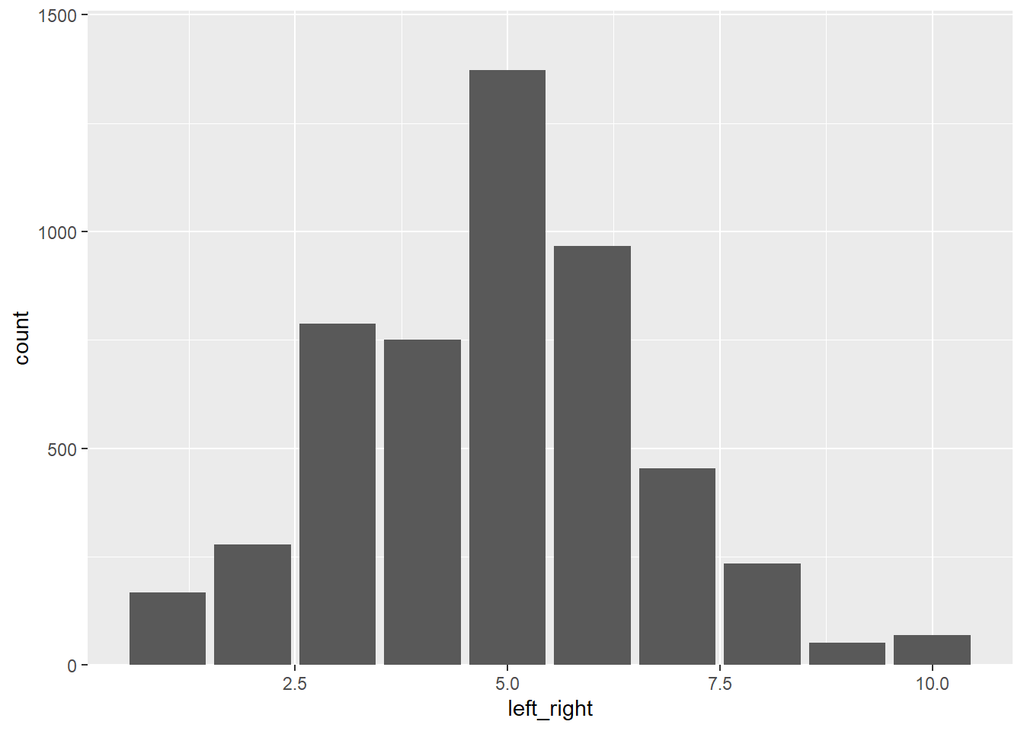

```r
allbus_2021_subset %>%
  ggplot(aes(x = left_right)) +
  geom_bar() +
  scale_y_continuous(expand=expansion(mult=c(0,0.1)))
```

## 2.4 Party affiliation and xenophobic attitudes

How do xenophobic attitudes differ between supporters of different parties?

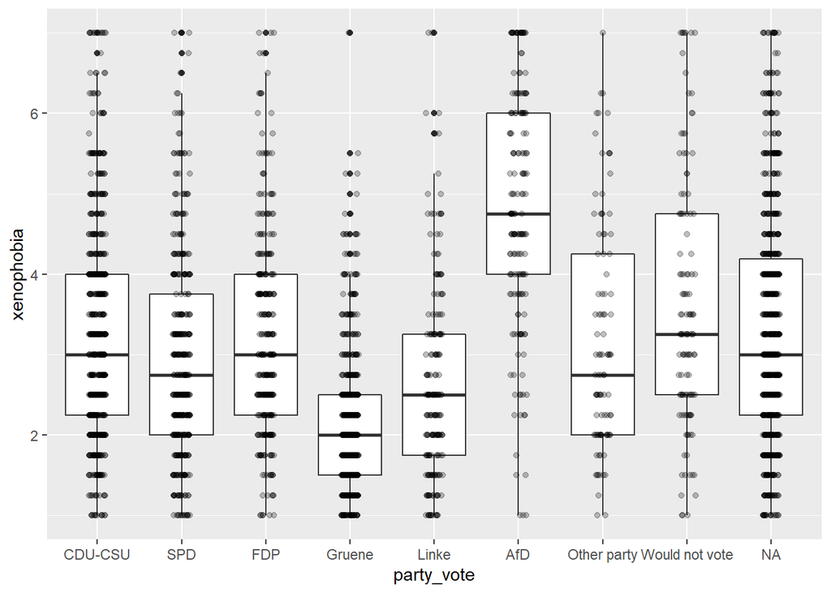

```r
allbus_2021_subset %>%
  ggplot(aes(x = party_vote, y = xenophobia)) +
  geom_boxplot() +
  geom_jitter(position = position_jitter(width = 0.1, height = 0),
              alpha = 0.25)
```

# 3 Analyses

## 3.1 Correlations

We want to explore the correlations between political leaning, xenophobia, and life satisfaction.

```r
library(correlation)
library(GGally)

allbus_2021_subset %>%
  select(left_right,
         xeno1:xeno4,
        life_satf) %>%
  correlation %>%
  knitr::kable()
```

| Parameter1 | Parameter2 | r | CI | CI_low | CI_high | t | df_error | p | Method | n_Obs |
| --- | --- | --- | --- | --- | --- | --- | --- | --- | --- | --- |
| left_right | xeno1 | 0.3425287 | 0.95 | 0.3114536 | 0.3728719 | 20.5367516 | 3173 | 0.0000000 | Pearson correlation | 3175 |
| left_right | xeno2 | 0.3004089 | 0.95 | 0.2683769 | 0.3317774 | 17.7133353 | 3163 | 0.0000000 | Pearson correlation | 3165 |
| left_right | xeno3 | 0.3049077 | 0.95 | 0.2729919 | 0.3361530 | 18.0197954 | 3168 | 0.0000000 | Pearson correlation | 3170 |
| left_right | xeno4 | 0.2342913 | 0.95 | 0.2011287 | 0.2669174 | 13.5689140 | 3170 | 0.0000000 | Pearson correlation | 3172 |
| left_right | life_satf | -0.0100479 | 0.95 | -0.0378962 | 0.0178160 | -0.7068251 | 4948 | 0.4797084 | Pearson correlation | 4950 |
| xeno1 | xeno2 | 0.4413642 | 0.95 | 0.4132793 | 0.4686102 | 28.0578635 | 3254 | 0.0000000 | Pearson correlation | 3256 |
| xeno1 | xeno3 | 0.4522287 | 0.95 | 0.4244893 | 0.4791201 | 28.9412014 | 3258 | 0.0000000 | Pearson correlation | 3260 |
| xeno1 | xeno4 | 0.2946897 | 0.95 | 0.2630308 | 0.3257146 | 17.6076253 | 3260 | 0.0000000 | Pearson correlation | 3262 |
| xeno1 | life_satf | -0.0495143 | 0.95 | -0.0842540 | -0.0146544 | -2.7846043 | 3155 | 0.0107825 | Pearson correlation | 3157 |
| xeno2 | xeno3 | 0.6218878 | 0.95 | 0.6003555 | 0.6425192 | 45.2862753 | 3252 | 0.0000000 | Pearson correlation | 3254 |
| xeno2 | xeno4 | 0.5345694 | 0.95 | 0.5095642 | 0.5586724 | 36.0654906 | 3251 | 0.0000000 | Pearson correlation | 3253 |
| xeno2 | life_satf | -0.1362712 | 0.95 | -0.1704058 | -0.1018099 | -7.7128648 | 3144 | 0.0000000 | Pearson correlation | 3146 |
| xeno3 | xeno4 | 0.5173153 | 0.95 | 0.4917102 | 0.5420265 | 34.4927476 | 3256 | 0.0000000 | Pearson correlation | 3258 |
| xeno3 | life_satf | -0.0922896 | 0.95 | -0.1268158 | -0.0575401 | -5.1986397 | 3146 | 0.0000006 | Pearson correlation | 3148 |
| xeno4 | life_satf | -0.1157135 | 0.95 | -0.1500257 | -0.0811229 | -6.5372863 | 3149 | 0.0000000 | Pearson correlation | 3151 |

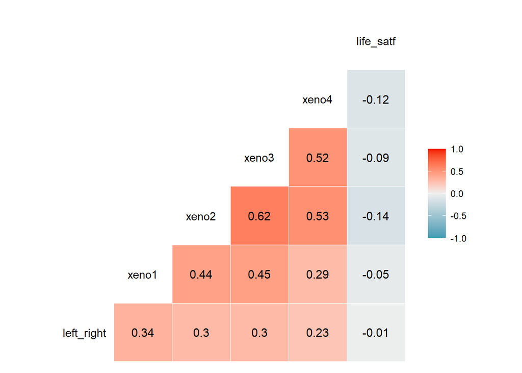

```r
allbus_2021_subset %>%
  select(left_right,
         xeno1:xeno4,
         life_satf) %>%
  ggcorr(label = TRUE,
         label_round = 2)
```

## 3.2 Regression analysis

```r
allbus_2021_subset <- allbus_2021_subset %>%
  mutate(distrust_gov_dic = ifelse(distrust_gov > 4, 0, 1))

library(broom)

model <- glm(distrust_gov_dic ~ 1 + life_satf + contact + xenophobia,
             family = binomial(link = "logit"),
             data = allbus_2021_subset)

tidy_model <- model %>%
  tidy()

tidy_model %>%
  knitr::kable()
```

| term | estimate | std.error | statistic | p.value |
| --- | --- | --- | --- | --- |
| (Intercept) | 0.5337357 | 0.3051168 | 1.749283 | 0.0802420 |
| life_satf | 0.2193902 | 0.0315883 | 6.945294 | 0.0000000 |
| contact | -0.1137927 | 0.0485351 | -2.344544 | 0.0190504 |
| xenophobia | -0.3842072 | 0.0452828 | -8.484614 | 0.0000000 |

```r
glance(model)
```

| null.deviance | df.null | logLik | AIC | BIC | deviance | df.residual | nobs |
| --- | --- | --- | --- | --- | --- | --- | --- |
| 1743.996 | 1365 | -801.871 | 1611.742 | 1632.62 | 1603.742 | 1362 | 1366 |

The unstandardized regression coefficients *b* can be selected from the `tidy_model`.

### 3.2.1 Regression plots

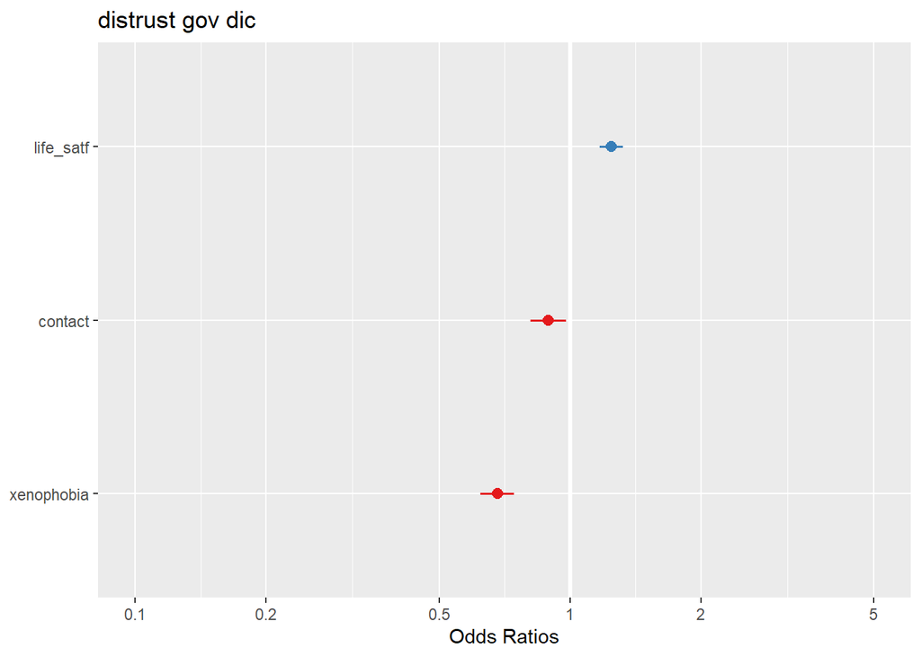

```r
library(sjPlot)

plot_model(model)
```

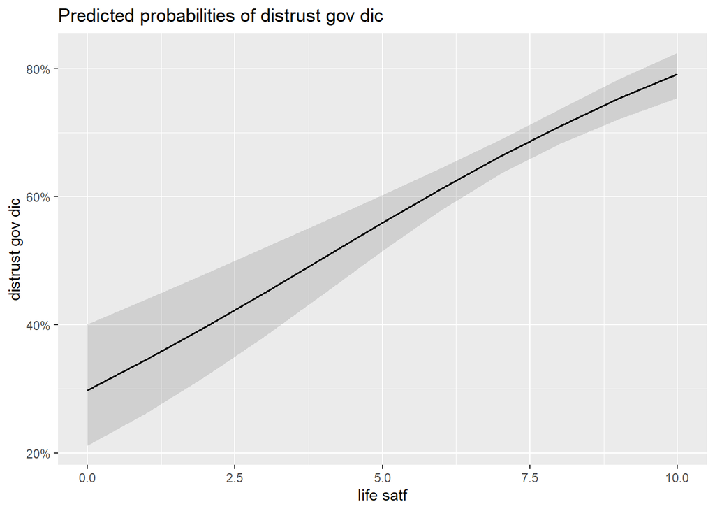

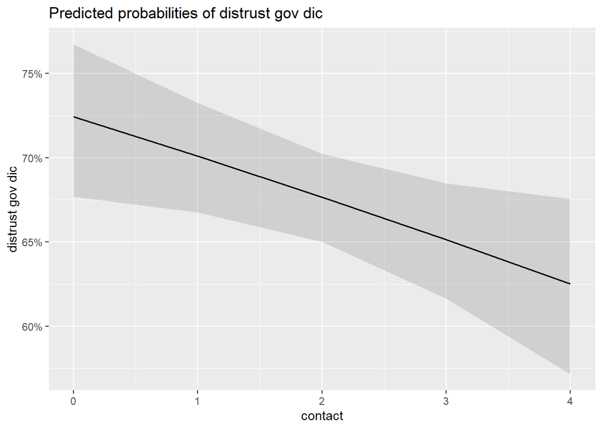

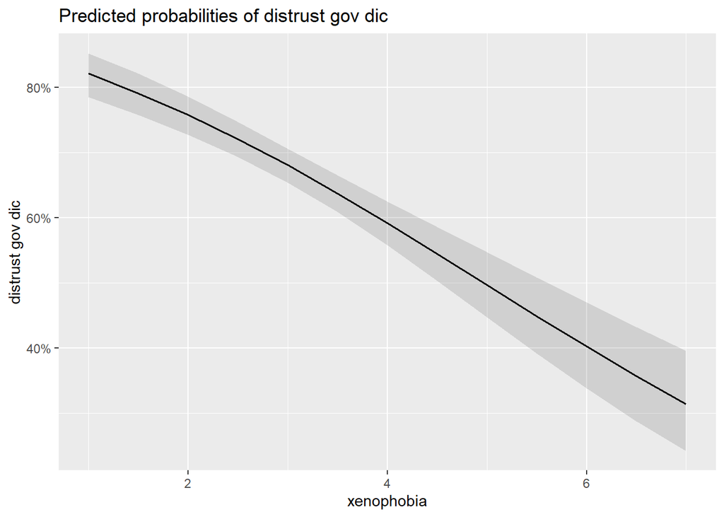

```r
plot_model(model,
           type = "pred")
```